# Part I - (Ford GoBike System Data ExplORation 2025)

### Which numerical variable correlations are positive, and which are negative?

```python
numeric_columns= ['age', 'distance', 'speed', 'start_hour', 'end_hour']
categorical_columns = ['gender', 'start_weekday', 'day_sequence']
```

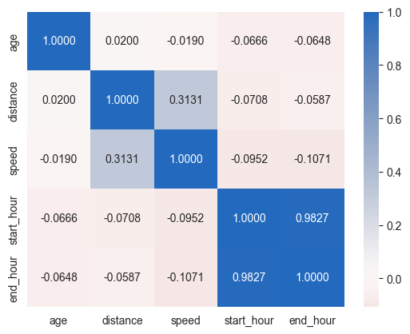

```python
sns.heatmap(df[numeric_columns].corr(), annot= True, fmt='.4f', cmap= 'vlag_r', center = 0);
```

> This heatmap plot indicates positive or negative relation between numerical variables. As illustratd in Multivariate Plot Matrix

> Each annotation number in a heatmap typically indicates the correlation coefficient(r) between two variables. This coefficient represents the strength and direction of the linear relationship between the two variables, ranging from -1 (perfect negative correlation) to +1 (perfect or strong positive correlation), with 0 indicating a weak correlation. Positive values indicate a direct relationship, while negative values suggest an inverse relationship.

### Correlation between Numerical and Categorical Variables

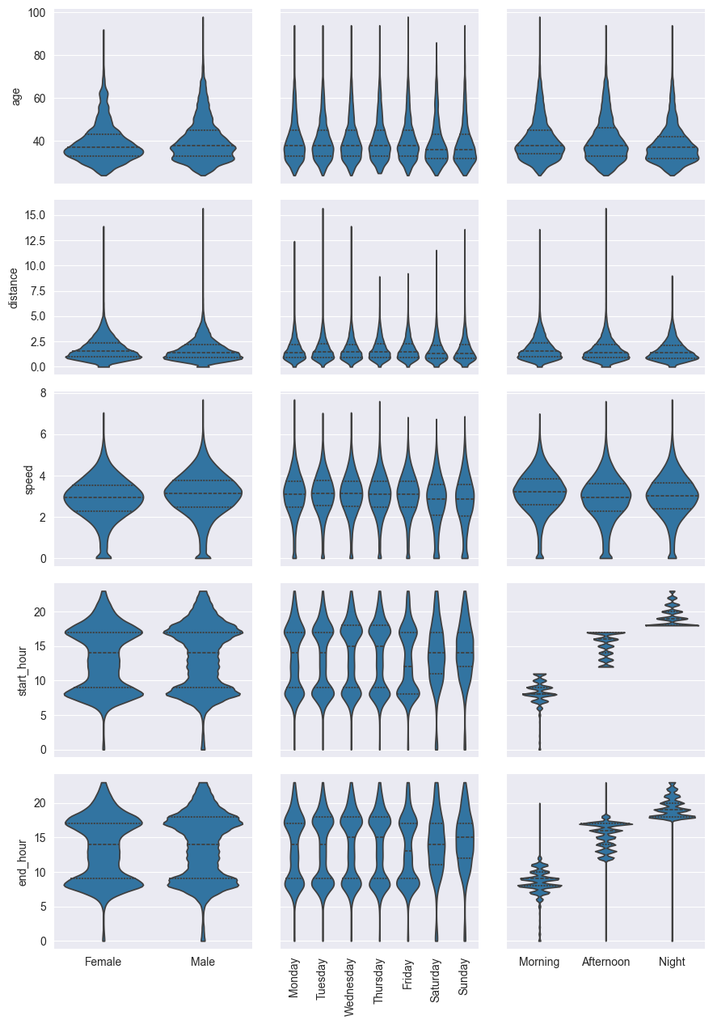

```python
g = sns.PairGrid(data = df, y_vars = numeric_columns, x_vars = categorical_columns,aspect=1.2)
g.map(sns.violinplot, inner='quartile', cut=0);   # Cut to reduce kernel density extent #limiting the KDE to the exact range of the data
g.axes[4,1].tick_params(axis='x', rotation=90)
for ax in g.axes.flat:
    ax.set_xlabel('')
```

> Starting and ending times peak during the morning and afternoon hours on working days, corresponding to rush hours.  
> However, on weekends, the distribution shifts, with starting and ending times predominantly occurring in the afternoon, with slightly lower average speed, reflecting leisure-oriented trips.

### Talk about some of the relationships you observed in this part of the investigation. How did the feature(s) of interest vary with other features in the dataset?

> The distance and duration of trips show a positive correlation, while age does not appear to have a significant impact, likely due to the majority of riders being in the 30 to 40-year-old range. Most trips occur in the morning on working days, while the highest number of trips takes place in the afternoon on weekends. The peak morning hour is at 8:00 AM, while in the afternoon, it is at 5:00 PM, and the peak hour during the night is at 6:00 PM.

> Thursday records the highest total trip number, but both Saturday and Sunday show higher average trip durations compared to weekdays. Over the course of the week, the average distance traveled remains relatively consistent. In the afternoon, trips generally have longer durations but cover shorter distances compared to the morning period. Afternoon trips also have a slightly longer average duration and lower average trip speed. Mornings, on the other hand, have the highest average trip distances, while nights tend to feature the shortest trips but faster speeds due to lighter traffic. Overall, the afternoons are characterized by longer durations and slower speeds.

### Did you observe any interesting relationships between the other features (not the main feature(s) of interest)?

> The majority of both men and women do not participate in the bike-sharing program. Most individuals are subscribers rather than customers, with more males participating than females. Furthermore, the number of subscribers consistently exceeds the number of customers across all genders, emphasizing a clear preference for the subscription-based model.

## Multivariate Exploration

### What is the Average Speed by Gender?

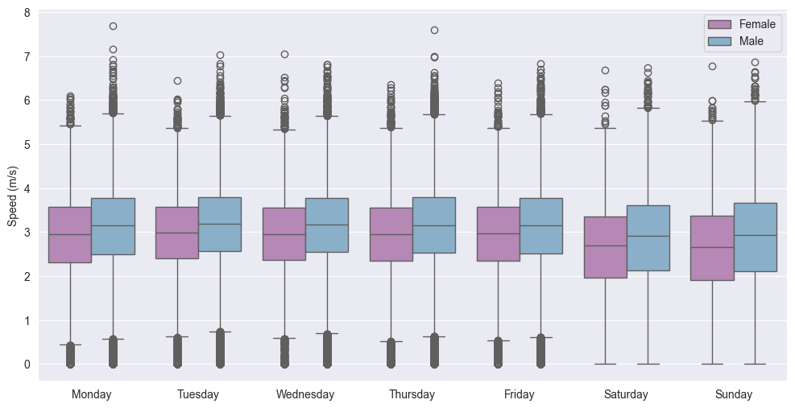

```python
plt.figure(figsize=(12, 6))
member_gender_colors = {'Female': sns.color_palette('Set3')[9], 'Male':sns.color_palette('Set3')[4]}
sns.boxplot(data=df, y='speed', x='start_weekday', hue='gender', palette=member_gender_colors)
plt.legend(title='')
plt.xlabel('')
plt.ylabel('Speed (m/s)');
```

> Men tend to have a slightly higher average speed throughout the week, as the number of male riders is twice that of female riders. In contrast, women’s average speed is generally aligned with the overall average, showing little variation.

### How do Trip Durations differ between Customers and Subscribers Throughout the Week?

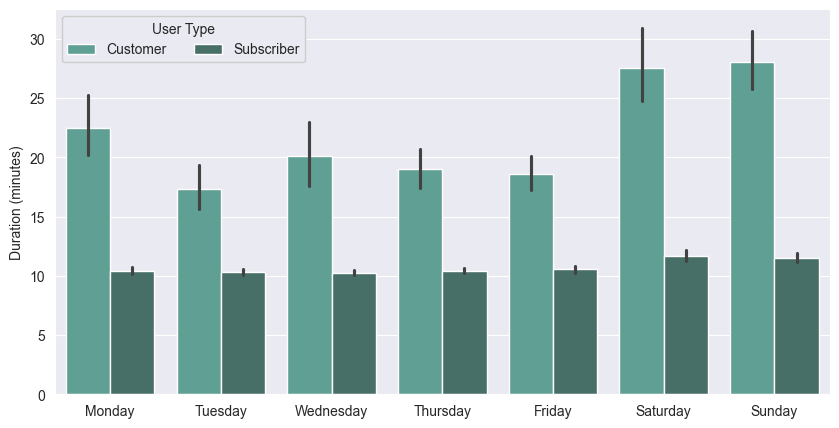

```python
user_type_plot(multi_var=True)
```

> Customers consistently have higher average trip durations compared to subscribers across all days of the week.

> Customer durations peak on weekends (Saturday and Sunday), likely due to leisure activities.

> Subscribers maintain a relatively stable duration throughout the week, while customers show notable variation.

### How do Trip Distance and Duration vary between Customers and Subscribers across Weekdays and Weekends?

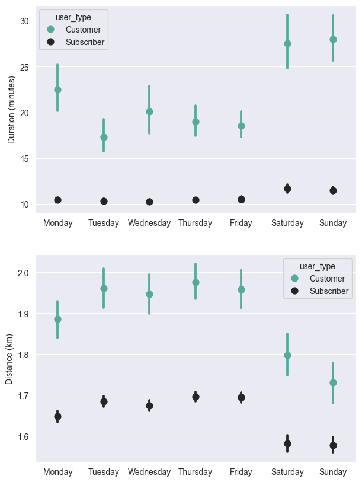

```python
plt.figure(figsize=(7, 10))

# Create subplots
plt.subplot(2, 1, 1)
ax1 = sns.pointplot(data=df, x='start_weekday', y='duration_minutes', hue='user_type',
                    palette='dark:#5A9_r',linestyles='', order=ordered_days)
ax1.set_xlabel('')
ax1.set_ylabel('Duration (minutes)')

plt.subplot(2, 1, 2)
ax2 = sns.pointplot(data=df, x='start_weekday', y='distance', hue='user_type',
                    palette='dark:#5A9_r',linestyles='', order=ordered_days)
ax2.set_xlabel('')
ax2.set_ylabel('Distance (km)');
```

> Customers' trips are significantly longer in both distance and duration compared to subscribers' trips, regardless of the day of the week.

> For both customers and subscribers, trips tend to last longer but cover shorter distances on weekends compared to weekdays. This pattern suggests that, on weekends, most people use the bikes primarily for leisure activities.

### What is the Relationship between Trip Duration, Distance, and Start Hour?

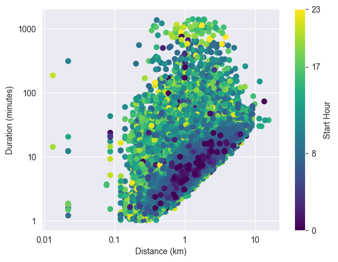

```python
plt.scatter(data=df, x='distance', y='duration_minutes', c='start_hour' , cmap='viridis')

# Add a color bar
cbar=plt.colorbar()

# Add a title or label to the color bar
cbar.set_label('Start Hour')
cbar.set_ticks([0, 8, 17, 23])
plt.xscale('log')
plt.yscale('log')

plt.xticks([0.01,0.1,1,10], labels=[0.01,0.1,1,10])
plt.yticks([1,10,100,1000], labels=[1,10,100,1000])

plt.xlabel('Distance (km)')
plt.ylabel('Duration (minutes)');
```

> This not just a piece of art, it indicates a clear positive trend between trip distance and duration—longer distances generally correspond to longer trip durations.

> Trips starting earlier in the day (darker points) are distributed across varying durations and distances.

> As the start hour increases (yellow points), longer trips appear more prominent, suggesting that longer trips are more frequent during the later parts of the day.

> Most trips cluster between 100m and 10km for distances, and between 1 and 100 minutes for durations.

### How does the Time of Day on a Weekday affect Trip Distances?

```python
def set_sample(dataframe, sample_size):
    sample = np.random.choice(dataframe.shape[0], sample_size, replace = False)
    subset_df = df.iloc[sample]
    return subset_df
```

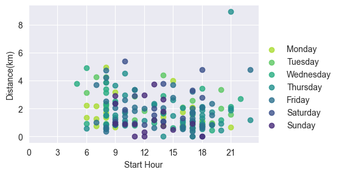

```python
subset_df = set_sample(df,200)

g = sns.FacetGrid(data=subset_df, hue='start_weekday',
               aspect=1.5, palette='viridis_r')
g.map(sns.regplot,'start_hour','distance', fit_reg=False);
g.add_legend(title='')
plt.xlabel('Start Hour')
plt.ylabel('Distance(km)');
plt.xticks([0,3,6,9,12,15,18,21]);
```

> The majority of trips across all days cover shorter distances, typically under 3 km, suggesting that bikes are primarily used for short commutes. There is a noticeable clustering of trips during peak commuting hours (8-9 AM and 17-19 PM), likely reflecting their use for daily commutes.

### How do Time of Day and Speed affect Travel Distances ?

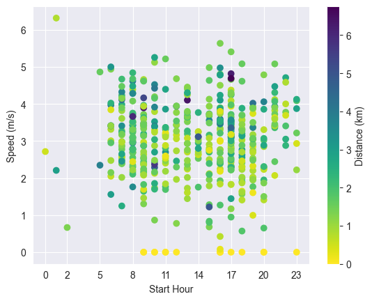

```python
subset_df = set_sample(df,500)
plt.scatter(data=subset_df, x='start_hour', y='speed', c='distance', cmap='viridis_r')
plt.colorbar(label='Distance (km)')

plt.xticks([0,2,5,8,11,14,17,20,23], [0,2,5,8,11,14,17,20,23])
plt.xlabel('Start Hour')
plt.ylabel('Speed (m/s)');
```

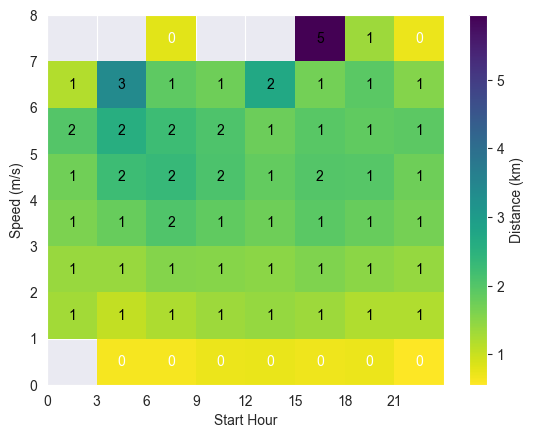

```python
plot_hist_2d(df, bins_x = np.arange(0, 23+3, 3), bins_y = np.arange(0, 8+1, 1),column_x='start_hour',column_y='speed',
            cmap_colors='viridis',ticks_x=[0,3,6,9,12,15,18,21],dark_value=1,bin_x_i=1.5,bin_y_j=0.5,
            unit_y='m/s',column_bar='distance', unit_bar='km')
```

> The most frequent distance traveled is 1 km, with the average range typically falling between 1 and 2 km. Instances of traveling 3 km occur, usually at speeds of 6-7 m/s, between the hours of 3-6. This is likely because there is no congestion during these hours, allowing users to maintain higher speeds.

> There are instances when no distance is traveled, particularly at lower speeds (0 m/s), across various start hours. This may be the result of waiting, stops, or pauses in movement, as users may be temporarily inactive due to congestion, delays, or technical reasons.

> A notable exception occurs between hours 15-18, when a maximum distance of 5 km is recorded at higher speeds (7 m/s and 8 m/s).

How do Distance and Time of Day influence Trip Durations?

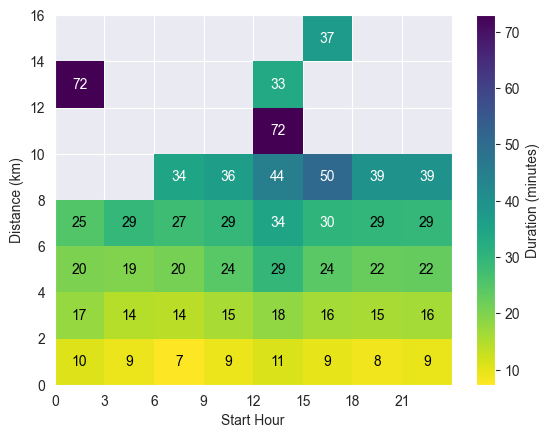

```python
plot_hist_2d(df,bins_x = np.arange(0, 23+3, 3), bins_y = np.arange(0, 16+2, 2), column_x='start_hour', column_y='distance',
             cmap_colors='viridis_r', ticks_x=[0,3,6,9,12,15,18,21], dark_value=30, bin_x_i=1.5, bin_y_j=1, unit_y='km',
             column_bar='duration_minutes')
```

> Throughout the day, duration generally increases with distance, particularly between 8 km and 12 km. For shorter distances under 8 km, duration remains consistent across various start hours, likely reflecting travel at an average speed of 3 m/s. The shortest trips, lasting around 7 minutes, are observed for 2 km distances during 6-9 AM, possibly due to faster speeds and lighter traffic in the early morning before peak congestion.

> The longest durations, reaching 72 minutes (1 hour and 12 minutes), are recorded for 12-14 km trips between 0-3 AM, likely due to uninterrupted travel at a steady speed of 3 m/s. A similar peak in duration occurs midday (12-15 hours) for 10-12 km trips, also at an average speed of 3 m/s, but likely influenced by increased congestion and delays during these busy hours.

### What is the Relationship between Age and Trip Duration in the Bike-Sharing System?

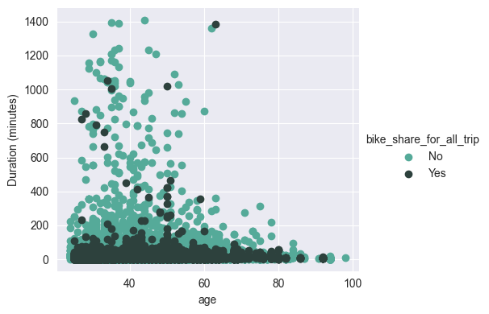

```python
bike_sharing_colors = {'No': sns.color_palette('dark:#5A9_r')[0], 'Yes':sns.color_palette('dark:#5A9_r')[4]}
g = sns.FacetGrid(data = df, hue = 'bike_share_for_all_trip', palette=bike_sharing_colors, height=4, aspect=1.2)
g.map(plt.scatter, 'age', 'duration_minutes')
g.add_legend();
plt.ylabel('Duration (minutes)');
```

### How does Distance influence Duration across Age Groups?

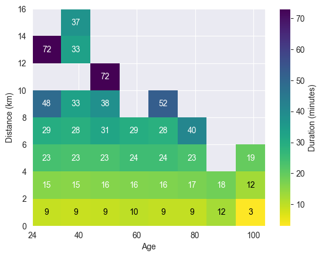

```python
plot_hist_2d(df,bins_x=np.arange(24, 100+10, 10), bins_y=np.arange(0, 16+2, 2), column_x='age', column_y='distance',
             cmap_colors='viridis_r', ticks_x=[24,40,60,80,100], dark_value=15, bin_x_i=5, bin_y_j=1, unit_y='km',
             column_bar='duration_minutes')
```

> The highest duration, approximately 72 minutes (1 hour and 12 minutes), is observed in the 24-50 age groups for a distance of 10-14 kilometers, which aligns with an average speed of 3 m/s.

### Is there a relationship between Age, Distance and Speed ?

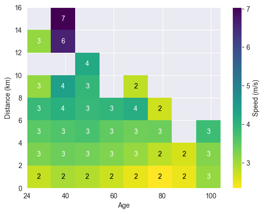

```python
plot_hist_2d(df,np.arange(24, 100+10, 10),np.arange(0, 16+2, 2),'age','distance', 'viridis_r',
            [24,40,60,80,100], 3, 5, 1 ,unit_y='km',column_bar='speed', unit_bar='m/s')
```

> Moderate speeds (3 to 4 m/s) are evenly distributed across various ages and distances, showing that individuals of different ages can sustain these speeds over different distances.

> Younger individuals (ages 30 to 40) maintain higher speeds (6 to 7 m/s) when covering longer distances (12 to 16 km).

> Older individuals (ages 80 to 90) tend to exhibit lower speeds (around 2 m/s) when covering shorter distances (0 to 8 km).

### Do Gender and Subscription influence the Length and Speed of Trips?

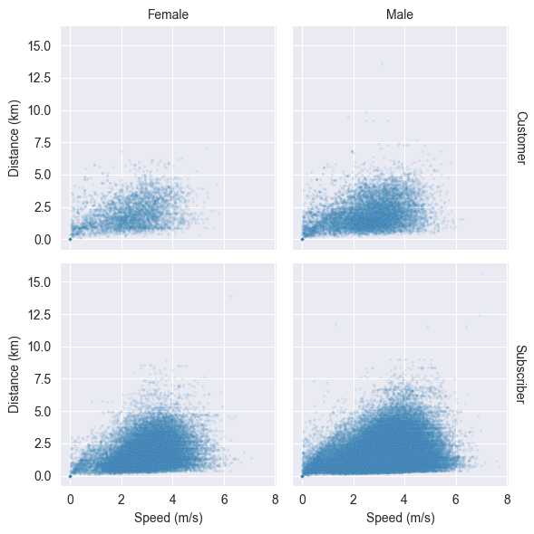

```python
g = sns.FacetGrid(data=df, col='gender', row='user_type', margin_titles=True)
g.map(sns.scatterplot, 'speed', 'distance', alpha=1/10 , s=5)  # Adjust the dot size using 's' parameter

# Set x and y-axis labels for all plots
g.set_axis_labels("Speed (m/s)", "Distance (km)")

g.set_titles(row_template="{row_name}", col_template="{col_name}");
```

### How do Trip Durations vary Across Key Stations?

```python
top_ten_start = df['start_station_name'].value_counts().iloc[:10].index
top_ten_end = df['end_station_name'].value_counts().iloc[:10].index
```

```python
df['same_station'] =  (df['start_station_id'] == df['end_station_id'])
```

```python
station_df = df[df['start_station_name'].isin(top_ten_start) & df['end_station_name'].isin(top_ten_end)]
station_df[station_df['same_station']==True].shape
```

```
(312, 22)
```

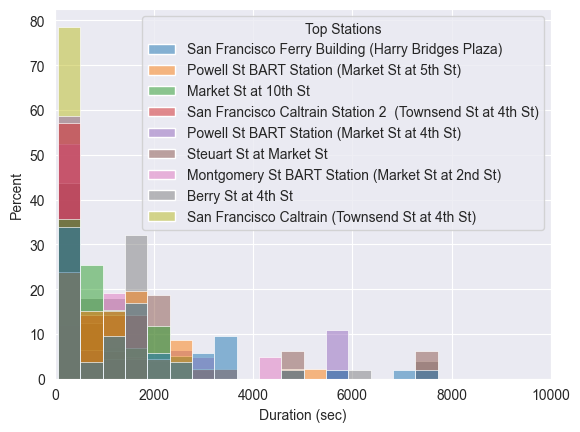

```python
ax=sns.histplot(data=station_df[station_df['same_station']==True],  x='duration_sec', hue='start_station_name',
             stat='percent', common_norm=False)

plt.xlabel('Duration (sec)')
plt.xlim(0,10000);
ax.legend_.set_title('Top Stations')
```

> The majority of trips across all stations have shorter durations, primarily under 2000 seconds (about 33 minutes).

> The station with a percentage between 70-80% is *San Francisco Caltrain Station (Townsend St at 4th St)*. This indicates that a significant proportion of trips from this station are shorter in duration. This trend aligns with the station's relatively low mean duration of 300.57 seconds, reflecting shorter commutes for its users.

> The *San Francisco Ferry Building (Harry Bridges Plaza)*, consistently appear across multiple trip durations, signifying steady utilization across varying trip durations.

#### Correlation Matrix

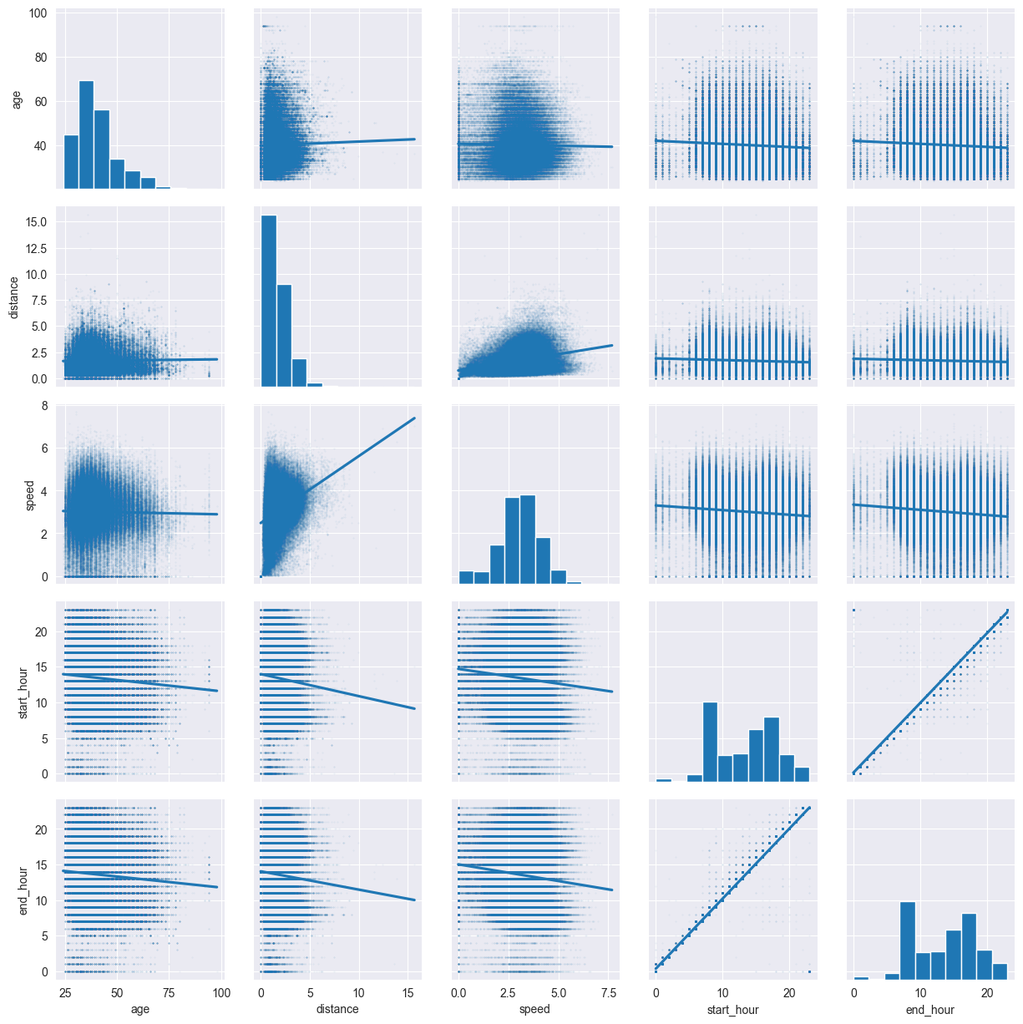

```python
g = sns.PairGrid(data = df, vars = numeric_columns)
g = g.map_diag(plt.hist)

g.map_offdiag(sns.regplot, scatter_kws={"s": 0.1, "alpha": 1/10}, ci=None);
```

### Correlations between different variables

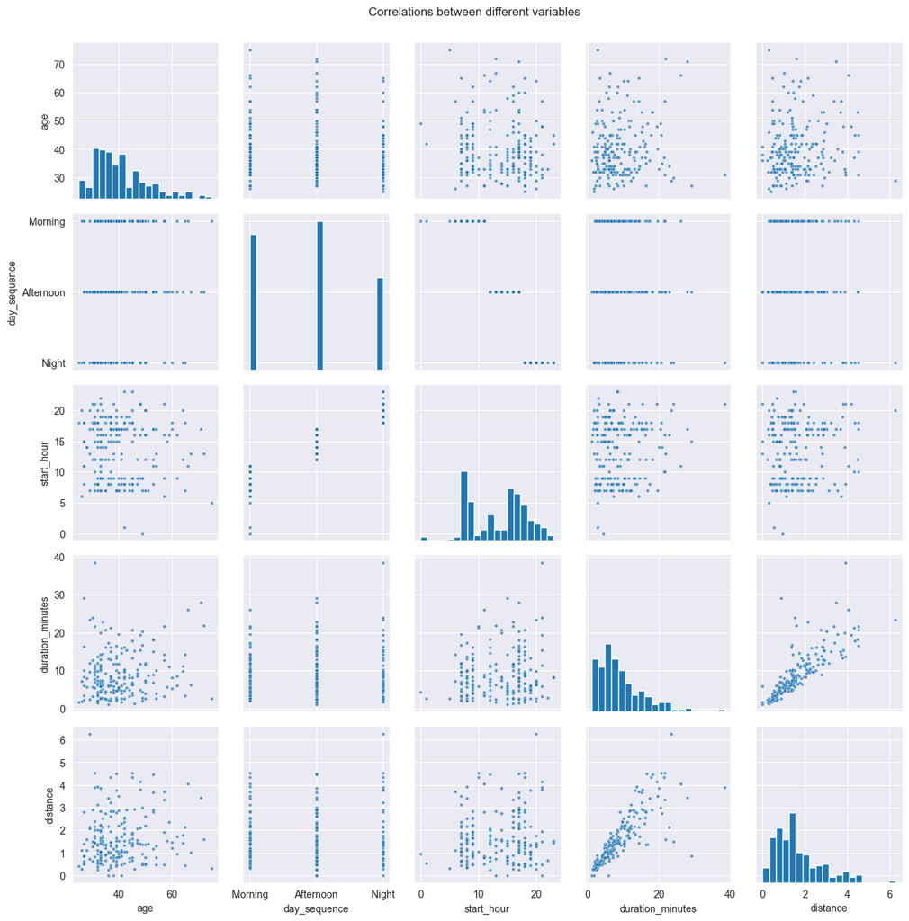

```python
# PairGrid Plot to visualize relations between different variables
subset_df=set_sample(df,200)
g = sns.PairGrid(data = subset_df, vars = ['age','day_sequence', 'start_hour','duration_minutes', 'distance'])
g.map_diag(plt.hist, bins=20)
g.map_offdiag(sns.scatterplot,s=10, alpha=0.7)
g.figure.suptitle('Correlations between different variables', y=1.02);
```

### Talk about some of the relationships you observed in this part of the investigation. Were there features that strengthened each other in terms of looking at your feature(s) of interest?

> Duration and distance demonstrated a strong direct relationship in most cases, as longer trips generally covered greater distances.

### Were there any interesting or surprising interactions between features?

> An interesting interaction between features is that although subscribers make more frequent trips, their durations remain stable throughout the week, suggesting regular, routine use such as commuting. In contrast, customers have longer average trip durations, with a marked increase on weekends, indicating their trips are more recreational and less routine. This contrast highlights a clear difference in trip purposes, subscribers favor shorter, efficient trips, while customers engage in fewer but longer trips, typically for leisure. Additionally, both customer and subscriber trips tend to be longer in duration but cover shorter distances on weekends, reinforcing the idea that weekends are more focused on leisure activities.

## Conclusions

> The majority of journeys are less than 1,000 seconds, while only a small proportion exceed 2,000 seconds.

> There is no clear linear relationship between age and trip distance or duration, highlighting variability in these factors across different age groups.

> Subscribers outnumber customers significantly in trip count across all days, especially on weekdays. This indicates that subscribers rely heavily on the service, likely for frequent, routine trips such as commuting.

> Despite making fewer trips, customers spend more time on their trips compared to subscribers. This suggests that customer trips may be less routine and more leisurely, such as recreational outings, rather than daily commuting.

> The key takeaway is that subscribers prioritize frequent and shorter trips (focused on volume and efficiency), while customers engage in fewer but longer trips (focused on leisure or occasional purposes).

save cleaned data to csv

```python
df.to_csv('cleaned-201902-fordgobike-tripdata.csv')
```